# Beyond Back-Door Adjustment

Lecture 5 vignette

Author

Causal Inference — STATS 420

[figure not shown]

Back-door adjustment is not the only route to identification. This vignette studies two alternatives:

1. **front-door adjustment**, where a measured mediator carries the causal effect of treatment to the outcome;
2. **instrumental variables**, where an external source of treatment variation isolates part of the causal effect.

The two strategies solve different identification problems and require different causal assumptions. Neither is a generic substitute for an invalid back-door adjustment set.

# 1 Front-door adjustment: pooled rides and tipping

We use Chicago ride-sharing trips. The variables of interest are:

- $X$: the rider authorized a shared trip;
- $M$: the trip was actually pooled with another rider;
- $Y$: the rider left a tip;
- $C$: pickup area and time block, with date optionally added;
- `tc`: total non-tip cost

The data can be loaded as follows:

```python
cp = pd.read_parquet(Path("../data/carpool.parquet"))

# Remove the rows with missing values.
required = [
    "pickup_community_area",
    "dropoff_community_area",
    "fare",
    "tip",
    "trip_start_timestamp",
    "shared_trip_authorized",
    "trips_pooled",
]
cp = cp.dropna(subset=required).copy()

# Construct the variables of interest.
cp["X"] = cp["shared_trip_authorized"].astype(int)
cp["M"] = (cp["trips_pooled"] > 1).astype(int)
cp = cp.loc[~((cp["X"] == 0) & (cp["M"] == 1))].copy()
cp["Y"] = (cp["tip"] > 0).astype(int)

cp["time"] = pd.to_datetime(cp["trip_start_timestamp"], utc=True)
cp["date"] = cp["time"].dt.date
cp["hr2"] = cp["time"].dt.hour // 2
cp["tc"] = cp["fare"] + cp["additional_charges"]

cp = cp.loc[
    (cp["tc"] >= 2.5)
    & (cp["tc"] <= 50)
    & (cp["tc"] > 0)
    & (cp["tip"] / cp["tc"] <= 1)
].copy()

pd.DataFrame({
    "trips": [len(cp)],
    "authorized": [pct(cp["X"].mean())],
    "pooled": [pct(cp["M"].mean())],
    "positive_tip": [pct(cp["Y"].mean())],
}).style.hide(axis="index")
```

| trips | authorized | pooled | positive_tip |
| --- | --- | --- | --- |
| 4354854 | 27.73% | 19.39% | 15.96% |

Authorization is necessary for pooling in these data: when $X=0$, $M=1$ is not a feasible observation. This structural feature will matter below.

## 1.1 Identification through the mediator

The front-door graph allows unobserved confounding between authorization and tipping, represented by the dashed bidirected edge. Riders who allow pooling may be different in terms of frugality, expenditure, etc., compared to riders who do not. These latent factors may also influence the propensity to tip the driver. Identification is possible in this case because the effect of authorization on tipping is assumed to operate through actual pooling.

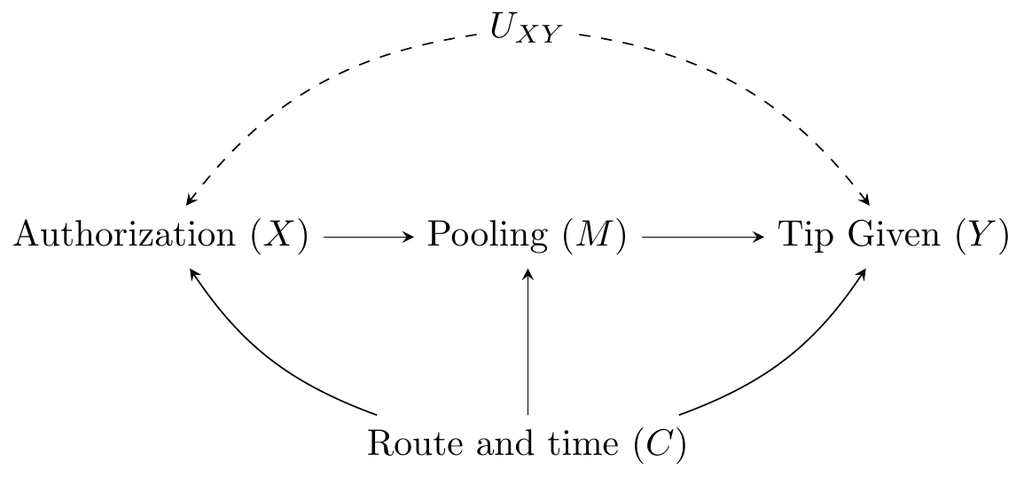

Conditional front-door graph for carpool authorization, pooling, and tipping.

Conditional on $C$ (we compare rides on similar routes and times), the front-door functional is

$$\begin{align}
\mu(x)
&= \sum_c P(c)\sum_m P(m\mid x,c)
\sum_{x'} \mathbb{E}[Y\mid m,x',c]P(x'\mid c),\\
ATE
&= \mu(1)-\mu(0).
\end{align}$$

The outer mediator distribution captures how authorization changes pooling. The inner average over $x'$ uses authorization as a back-door adjustment set for the effect of pooling on tipping—precisely the composition emphasized in the lecture.

**Front-door assumptions.** Given $C$, (i) $M$ intercepts all directed paths from $X$ to $Y$; (ii) there is no unblocked back-door path from $X$ to $M$; and (iii) $X$ blocks every back-door path from $M$ to $Y$. Consistency and the relevant positivity conditions are also required.

**NoteQuestion**

Which of these assumptions is most scientifically demanding in the carpool application?

## 1.2 A nonparametric plug-in estimator

The function below computes each term in the conditional front-door formula using empirical proportions and means. It retains strata containing both treatment levels and both feasible mediator levels among authorized trips.

Care needs to be taken, because the combination $(X=0,M=1)$ is absent (pooling is possible only if authorized). This makes it impossible to estimate the conditional mean $\mathbb{E}[Y \mid m_1, x_0, c]$ that appears in the above front-door expression. To avoid this issue, we add an explicit modeling assumption: no additive $X\times M$ interaction within the $f_Y$ mechanism. If

$$\begin{align}
\mu_{xm}(c)=\mathbb{E}[Y\mid X=x,M=m,C=c],
\end{align}$$

then the missing mean is imputed as

$$\begin{align}
\mu_{01}(c)=\mu_{00}(c)+\mu_{11}(c)-\mu_{10}(c).
\end{align}$$

```python
def fd_np(dat, C):
    # Identify strata containing every feasible X by M cell.
    cells = (
        dat.groupby(C + ["X", "M"], observed=True)
        .size()
        .unstack(["X", "M"], fill_value=0)
    )
    for cell in [(0, 0), (0, 1), (1, 0), (1, 1)]:
        if cell not in cells.columns:
            cells[cell] = 0

    keep = (
        (cells[(0, 0)] > 0)
        & (cells[(0, 1)] == 0)
        & (cells[(1, 0)] > 0)
        & (cells[(1, 1)] > 0)
    )
    valid = cells.index[keep].to_frame(index=False)
    d = dat.merge(valid, on=C, how="inner")

    # P(C), P(X | C), P(M | X,C), and E[Y | M,X,C].
    pc = d.groupby(C, observed=True).size().rename("N").reset_index()
    pc["pc"] = pc["N"] / len(d)

    px = d.groupby(C + ["X"], observed=True).size().rename("N").reset_index()
    px["px"] = px["N"] / px.groupby(C, observed=True)["N"].transform("sum")

    pm = d.groupby(C + ["X", "M"], observed=True).size().rename("N").reset_index()
    pm["pm"] = pm["N"] / pm.groupby(C + ["X"], observed=True)["N"].transform("sum")

    ey = d.groupby(C + ["M", "X"], observed=True)["Y"].mean().rename("ey").reset_index()

    # Infer the missing (X = 0, M = 1) cell under no X by M interaction.
    ey00 = ey.query("X == 0 and M == 0")[C + ["ey"]].rename(columns={"ey": "ey00"})
    ey10 = ey.query("X == 1 and M == 0")[C + ["ey"]].rename(columns={"ey": "ey10"})
    ey11 = ey.query("X == 1 and M == 1")[C + ["ey"]].rename(columns={"ey": "ey11"})

    ey0 = ey00.merge(ey10, on=C).merge(ey11, on=C)
    ey0["X"] = 0
    ey0["M"] = 1
    ey0["ey"] = ey0["ey00"] + ey0["ey11"] - ey0["ey10"]
    ey = pd.concat([ey, ey0[C + ["M", "X", "ey"]]], ignore_index=True)

    # sum_x' E[Y | m,x',c] P(x' | c)
    q = ey.merge(px[C + ["X", "px"]], on=C + ["X"])
    q["term"] = q["ey"] * q["px"]
    q = q.groupby(C + ["M"], observed=True)["term"].sum().rename("q").reset_index()

    # sum_m P(m | x,c) q(m,c), followed by averaging over C.
    mu = {}
    for x_value in (0, 1):
        r = pm.loc[pm["X"] == x_value, C + ["M", "pm"]].merge(q, on=C + ["M"])
        r["term"] = r["pm"] * r["q"]
        r = r.groupby(C, observed=True)["term"].sum().rename("mu").reset_index()
        r = r.merge(pc[C + ["pc"]], on=C)
        mu[x_value] = (r["mu"] * r["pc"]).sum()

    return {
        "mu0": mu[0],
        "mu1": mu[1],
        "est": mu[1] - mu[0],
        "n": len(d),
        "strata": len(valid),
    }
```

We first condition on pickup area and two-hour block, then add calendar date.

```python
fd = fd_np(cp, ["pickup_community_area", "hr2"])
fd_d = fd_np(cp, ["pickup_community_area", "hr2", "date"])

fd_results = pd.DataFrame({
    "Conditioning": [
        "Pickup area + time block",
        "Pickup area + time block + date",
    ],
    "Front-door estimate": pct([fd["est"], fd_d["est"]]),
    "Trips retained": [f'{fd["n"]:,}', f'{fd_d["n"]:,}'],
    "Strata": [f'{fd["strata"]:,}', f'{fd_d["strata"]:,}'],
})
```

Table 1: Nonparametric front-door estimates under two conditioning specifications.

| Conditioning | Front-door estimate | Trips retained | Strata |
| --- | --- | --- | --- |
| Pickup area + time block | -0.88% | 4,354,854 | 924 |
| Pickup area + time block + date | -0.91% | 4,346,174 | 15,830 |

Changing $C$ can change both adjustment and the population retained by the empirical positivity filter. A difference between the two rows is therefore not purely a measure of confounding control.

**NoteQuestion**

Why does adding date create a more demanding empirical positivity requirement?

## 1.3 A back-door comparison

For comparison, the following estimator computes the causal effect by assuming that $C$ is a valid back-door set for the effect of $X$ on $Y$.

```python
def bd_np(dat, C):
    cells = dat.groupby(C + ["X"], observed=True).size().unstack("X", fill_value=0)
    for x_value in (0, 1):
        if x_value not in cells.columns:
            cells[x_value] = 0

    valid = cells.index[(cells[0] > 0) & (cells[1] > 0)].to_frame(index=False)
    d = dat.merge(valid, on=C, how="inner")

    pc = d.groupby(C, observed=True).size().rename("N").reset_index()
    pc["pc"] = pc["N"] / len(d)

    ey = d.groupby(C + ["X"], observed=True)["Y"].mean().unstack("X").reset_index()
    ey = ey.rename(columns={0: "ey0", 1: "ey1"})
    out = ey.merge(pc[C + ["pc"]], on=C)
    estimate = ((out["ey1"] - out["ey0"]) * out["pc"]).sum()

    return {"est": estimate, "n": len(d), "strata": len(valid)}


bd = bd_np(cp, ["pickup_community_area", "hr2"])
bd_d = bd_np(cp, ["pickup_community_area", "hr2", "date"])

bd_results = pd.DataFrame({
    "Conditioning": [
        "Pickup area + time block",
        "Pickup area + time block + date",
    ],
    "Back-door contrast": pct([bd["est"], bd_d["est"]]),
    "Trips retained": [f'{bd["n"]:,}', f'{bd_d["n"]:,}'],
    "Strata": [f'{bd["strata"]:,}', f'{bd_d["strata"]:,}'],
})
```

Table 2: Standardized authorization–tipping contrasts.

| Conditioning | Back-door contrast | Trips retained | Strata |
| --- | --- | --- | --- |
| Pickup area + time block | -8.73% | 4,354,854 | 924 |
| Pickup area + time block + date | -8.64% | 4,353,737 | 16,626 |

These are causal back-door estimates only if $C$ blocks every back-door path from authorization to tipping. The front-door analysis was motivated precisely by concern about unmeasured $X$–$Y$ confounding, so the table is a comparison, not a ground truth benchmark.

**NoteQuestion**

Why can front-door and back-door calculations disagree even when both are computed accurately from the observed data?

The back-door estimate indicates a very strong negative effect of carpool authorization on tipping, around 9%. The front-door estimate indicates a much more modest effect, below 1%.

**NoteQuestion**

Which estimate do you trust more?

# 2 Instrumental variables: proximity and education

The second example uses Card’s schooling data. The treatment is years of education ($X$), the outcome is logarithm-of-wage ($Y$), and the candidate instrument is proximity to a four-year college (`nearc4`, denoted $Z$).

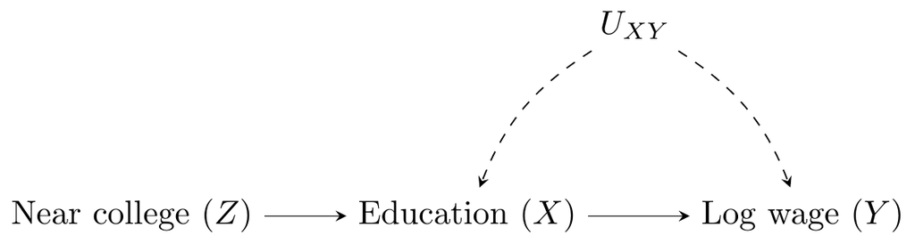

Instrumental-variable graph for proximity, education, and log wage.

**Instrumental-variable assumptions.** Conditional on the included covariates, $Z$ must predict education (**relevance**), share no unmeasured cause with log wage (**independence**), and affect log wage only through education (**exclusion**). A LATE interpretation additionally invokes monotonicity.

## 2.1 Two-stage least squares

The lecture’s two-stage construction is:

1. regress $X$ on $Z$ and the covariates $C$ to obtain fitted education $\widehat X$;
2. regress $Y$ on $\widehat X$ and $C$.

After residualizing all variables with respect to $C$, the just-identified IV coefficient can also be written as

$$\begin{align}
\widehat\beta_{\mathrm{IV}}
=\frac{\widetilde Z^{\mathsf T}\widetilde Y}
{\widetilde Z^{\mathsf T}\widetilde X}.
\end{align}$$

The numerator measures how the instrument shifts the outcome; the denominator measures how it shifts education. Their ratio converts the reduced-form effect of the instrument into an effect per additional year of education.

We compute both OLS and 2SLS directly from matrix products; no specialized IV estimation package is required.

```python
dat = pd.read_parquet(Path("../data/card.parquet"))

y = dat["lwage"].to_numpy()
x = dat["educ"].to_numpy()
z = dat["nearc4"].to_numpy()

cn = [
    "exper", "expersq", "black", "south", "smsa",
    "reg661", "reg662", "reg663", "reg664", "reg665",
    "reg666", "reg667", "reg668", "smsa66",
]

# Regressors contain an intercept, the covariates, and education.
C = sm.add_constant(dat[cn]).to_numpy()
regressors = np.column_stack([C, x])

# Instruments contain an intercept, the covariates, and nearc4.
instruments = np.column_stack([C, z])

# OLS.
ols = sm.OLS(y, regressors).fit()
ols_estimate = ols.params[-1]
ols_interval = ols.conf_int(alpha=0.05)[-1]

# 2SLS, using cross-products to apply the instrument-space projection.
inv_ztz = np.linalg.inv(instruments.T @ instruments)
ztx = instruments.T @ regressors
zty = instruments.T @ y
xpzx = ztx.T @ inv_ztz @ ztx
xpzy = ztx.T @ inv_ztz @ zty

beta_2sls = np.linalg.solve(xpzx, xpzy)

residuals = y - regressors @ beta_2sls
sigma2 = residuals @ residuals / (len(y) - regressors.shape[1])
vcov_2sls = sigma2 * np.linalg.inv(xpzx)
se_2sls = np.sqrt(np.diag(vcov_2sls))

iv_estimate = beta_2sls[-1]
iv_interval = iv_estimate + np.array([-1, 1]) * 1.96 * se_2sls[-1]

iv_estimates = pd.DataFrame({
    "Estimator": ["OLS / k = 0", "2SLS / k = 1"],
    "Log-wage coefficient": [ols_estimate, iv_estimate],
    "95% CI: lower": [ols_interval[0], iv_interval[0]],
    "95% CI: upper": [ols_interval[1], iv_interval[1]],
})
iv_estimates["Exact wage change"] = pct(
    np.exp(iv_estimates["Log-wage coefficient"]) - 1
)
```

Table 3: OLS and 2SLS estimates for years of education and log wage.

| Estimator | Log-wage coefficient | Exact wage change | 95% CI |
| --- | --- | --- | --- |
| OLS / k = 0 | 0.075 | 7.76% | [0.068, 0.082] |
| 2SLS / k = 1 | 0.132 | 14.05% | [0.024, 0.239] |

**NoteQuestions**

1. Why is proximity to a four-year college plausibly relevant for education?
2. Which exclusion or independence violations remain scientifically possible?
3. Why does 2SLS usually have a wider confidence interval than OLS here?
4. Are the two causal effect estimates qualitatively different? Why?
5. What are possible unobserved common causes of $X$ and $Y$? How would they shift the effect?

# 3 Takeaways

| Strategy | Source of identification | Main requirement |
| --- | --- | --- |
| Front door | Treatment changes a mediator whose effect on the outcome can be recovered | Full mediation, mediator unconfounded, mediator positivity |
| Back-door comparison | Conditioning variables block all treatment–outcome back-door paths | No treatment–outcome confounding beyond observables |
| Instrumental variables | An external variable shifts treatment without otherwise shifting the outcome | Linearity, Exogeneity, Exclusion, Relevance |